Skip to main content

> **R or Rust?** The same functions and arguments exist in R (`verb(m, ...)` for Python’s `m.verb(...)`) and Rust.

basemapper renders MapLibre GL basemaps headlessly with a Rust core: no browser, display server, GPU or GDAL. Vector styles are drawn by a software port of MapLibre GL JS’s renderer, so maps look as they do in MapLibre. Everything on this page was run when the page was built; the maps are the output of the code above them.

# Installation

```bash
pip install "basemapper @ git+https://github.com/ar-puuk/basemapper#subdirectory=py-basemapper"
# or: uv add "basemapper @ git+https://github.com/ar-puuk/basemapper#subdirectory=py-basemapper"
```

See the home page for conda.

# Choose a style

Every function takes a `style`. The simplest is a named basemap, a [leaflet-providers](https://leaflet-extras.github.io/leaflet-providers/preview/) name; list_providers() lists them, with the API key some need:

```python
import basemapper as bm

for p in bm.list_providers()[:12]:
    print(f"{p['name']:<24} vector={p['vector']!s:<5} raster={p['raster']!s:<5} key={p['api_key_env']}")
```

```
OpenStreetMap.Mapnik     vector=False raster=True  key=None
OpenStreetMap.DE         vector=False raster=True  key=None
OpenStreetMap.France     vector=False raster=True  key=None
OpenStreetMap.HOT        vector=False raster=True  key=None
OpenTopoMap              vector=False raster=True  key=None
CyclOSM                  vector=False raster=True  key=None
OpenFreeMap.Liberty      vector=True  raster=False key=None
OpenFreeMap.Bright       vector=True  raster=False key=None
OpenFreeMap.Positron     vector=True  raster=False key=None
OpenFreeMap.Dark         vector=True  raster=False key=None
OpenFreeMap.Fiord        vector=True  raster=False key=None
CartoDB.Positron         vector=True  raster=True  key=CARTO_API_KEY
```

A MapLibre style URL or JSON works too, and so does tile data: a tile URL, TileJSON, PMTiles archive or ArcGIS service (see Your own tiles and services).

# A map on its own

basemap() creates a view: a centre and MapLibre zoom (or bounds to fit), and a size in CSS pixels. In a notebook, a view shows the map:

```python
m = bm.basemap("OpenFreeMap.Positron", 720, 405, center=(-111.8887, 40.7556), zoom=12.4)
m
```

[figure not shown]

`repr()` describes it, and the `get_*()` methods read it:

```python
print(repr(m))
print(m.get_bounds(lonlat=True))
print(m.get_attribution())
```

```
<Basemap 1 style, 720 x 405 @ 1x (720 x 405 px), center (-111.88870, 40.75560), zoom 12.400>
(-111.93553419871802, 40.73564121457685, -111.841865801282, 40.77555279531684)
OpenFreeMap © OpenMapTiles Data from OpenStreetMap
```

set_view() and set_bounds() change the view. Here it fits North Carolina’s counties (a GeoDataFrame, from [geodatasets](https://geodatasets.readthedocs.io)):

```python
import geopandas as gpd
import geodatasets

nc = gpd.read_file(geodatasets.get_path("geoda.sids"))
bm.basemap("OpenFreeMap.Liberty", 720, 300, bounds=nc)
```

[figure not shown]

# Raster and vector, PNG and SVG

Basemaps come as raster tiles (images, like OpenStreetMap’s) or vector tiles (geometry styled on the fly, like OpenFreeMap’s). Either renders to a PNG with render_png() or an SVG with render_svg(). In an SVG, vector layers are paths and the labels editable text with the style’s fonts embedded; raster tiles are embedded as images.

```python
import os, tempfile

slc = (-111.8910, 40.7608)
raster = bm.basemap("OpenStreetMap.Mapnik", 480, 300, center=slc, zoom=11.5)
vector = bm.basemap("OpenFreeMap.Bright", 480, 300, center=slc, zoom=11.5)

out = tempfile.mkdtemp()
for name, m in [("raster", raster), ("vector", vector)]:
    m.render_png(os.path.join(out, f"{name}.png"))
    m.render_svg(os.path.join(out, f"{name}.svg"))

for f in sorted(os.listdir(out)):
    print(f"{f:<12} {os.path.getsize(os.path.join(out, f)) // 1024} KB")
```

```
raster.png   228 KB
raster.svg   305 KB
vector.png   81 KB
vector.svg   429 KB
```

PNG

SVG

Raster  
OpenStreetMap

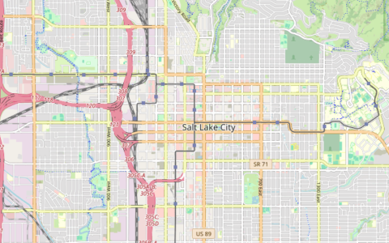

[figure not shown]

Vector  
OpenFreeMap Bright

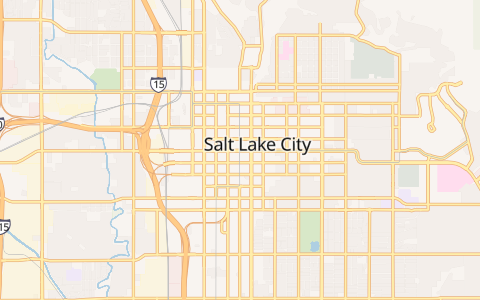

[figure not shown]

render_array() returns the pixels, for your own compositing, and get_bounds() their extent in Web Mercator:

```python
a = vector.render_array()
a.shape, a.dtype, vector.get_bounds()
```

```
((300, 480, 4),
 dtype('uint8'),
 (-12462135.04127428,
  4973069.79762207,
  -12449163.247426074,
  4981177.168777199))
```

`pixel_ratio` makes images larger with the same view and label layout: `pixel_ratio=2` for a sharp 2x image, `dpi / 96` for print.

# In a plot

add_basemap() adds a basemap under a matplotlib axes’ content. It renders when the figure is drawn, for the axes’ extent and at the output resolution, and credits the provider in the corner:

```python
import matplotlib.pyplot as plt

nc_3857 = nc.to_crs(3857)
fig, ax = plt.subplots(figsize=(8, 3.6))
nc_3857.plot(ax=ax, column="BIR74", cmap="viridis", alpha=0.75, edgecolor="white", linewidth=0.3, legend=True)
bm.add_basemap(ax, "OpenFreeMap.Positron", crs=3857)
ax.set_axis_off()
```

[figure not shown]

geom_basemap() does the same in plotnine, with the arguments of R’s geom_basemap():

```python
from plotnine import aes, geom_map, ggplot, scale_fill_cmap, theme_void, theme

(
    ggplot(nc)
    + bm.geom_basemap("Esri.WorldGrayCanvas")
    + geom_map(aes(fill="SID74"), alpha=0.7, color="white", size=0.2)
    + scale_fill_cmap("Blues", name="SIDS, 1974")
    + theme_void()
    + theme(figure_size=(8, 3.6))
)
```

[figure not shown]

Plots with matplotlib and plotnine has more.